# Stan

Jeffrey Chrabaszcz  
9 January 2014

### Outline

1. Statistical philosophy
2. Bayesian inference
3. Likelihood calculation for continuous variables
4. Maximizing likelihood
5. Markov chains

### Statistical philosophy

## Frequentist

- Pros
  - intuitive to run
  - influential
  - ubiquitous defaults
- Cons
  - limited application
  - abused
  - strange to interpret

## Bayesian

- Pros
  - flexible
  - easy interpretation
  - anwers the right question!
- Cons
  - complex computation
  - slow adoption

### Bayesian inference

In Bayesian inference, we generally consider:

- what we already know (priors)
- what we learn from our current observation (likelihood)
- how much our beliefs should change as a result of our observation (posterior)

### Prior

This should represent everything we know about our problem before we start.

- scale boundaries
- previous research
- related observations

Often a range of priors are appropriate. Rarely is a uniform prior appropriate.

### Likelihood

Assuming no other information, we can maximize the likelihood of the data by maximizing the objective function.

\[ \hat{\ell}(\theta|x) = \frac{1}{n}\sum_{i = 1}^n \ln f(x_i|\theta) \]

This is what we've already been doing with `lm()`!

### Posterior

The hard part about Bayesian statistics is combining the prior and likelihood functions to determine the posterior distribution. Done correctly, this yield an intuitive interpretation: what is the probability of a given parameter value.

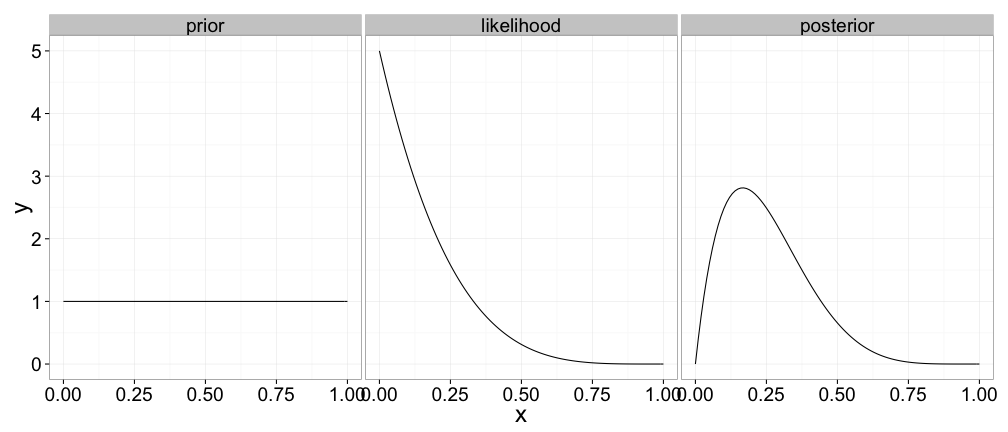

### Data!

How can you have a probability of something happen if you know it's happened?

\[ P(D|H1) + P(D|\neg H1) \]

\[ \sum_{i=1}^{k} P(D|H_i) \]

This is only letting us interpret things in direct probabilities rather than unnormalized ratios.

### Bayesian cancer updating

- 1% of women have breast cancer
- 80% of mammograms detect breast cancer given that it is present
- 90.4% of mammograms correctly return a negative result given that breast cancer is not present

## Question

| . | C | ~C |
| --- | --- | --- |
| Positive | .01 * .8 | .99 * .096 |
| Negative | .01 * .2 | .99 * .904 |

So we can solve this:

\[ P(C|Pos) = \frac{P(C \cap Pos)}{P(Pos)} = \frac{.01 \cdot .8}{(.01 \cdot .8 + .99 \cdot .096)} \]

```r
.01 * .8/(.01 * .8 + .99 * .096)
```

```
[1] 0.0776
```

### Likelihood calculation for continuous variable

The normal distribution is defined for all possible values of X. Say we sample five values from a standard normal distribution.

```
[1] -0.450 -0.315  1.138 -1.619  0.110
```

We can visualize the probability density associated with each of these samples assuming \( \mu = 0 \) and \( \sigma = 1 \) on the following graph.

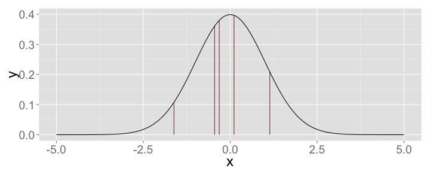

### Heights of lines

The heights of those lines are dictated by the parameters of the normal distribution. That means we can change the heights by changing the parameters!

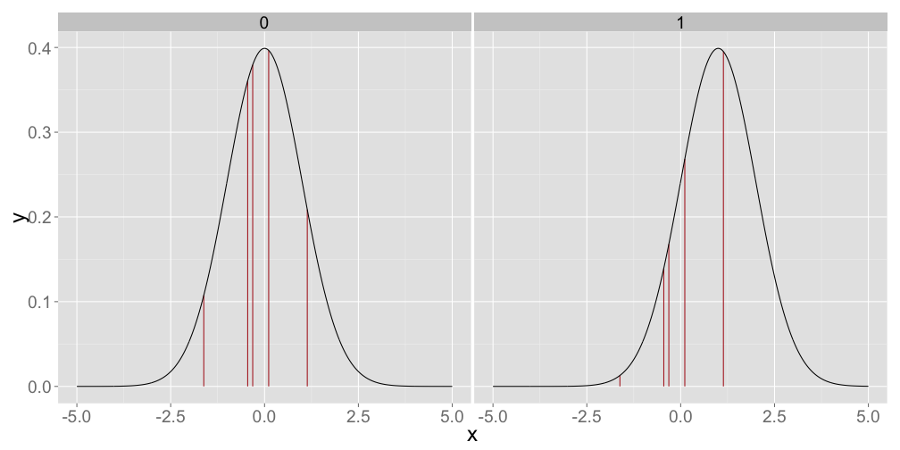

### Maximizing likelihood

```r
logL <- function(coefs, y, x, sdr) {
  means <- coefs[1] + coefs[2] * x
  dat <- cbind(y, means, sdr)
  ll <- apply(dat, 1, function(x) dnorm(x[1], mean = x[2], sd = x[3]))
  return(sum(log(ll)))
}
bootS <- function(model.formula, df) {
  new.df <- df[sample(nrow(df), nrow(df), replace = TRUE),]
  mod <- lm(model.formula, data = new.df)
  return(coef(mod))
}
getRSD <- function(coefs, y, x) {
  y.hat <- coefs[1] + coefs[2] * x
  resids <- y - y.hat
  return(sd(resids))
}
```

### Outputs for ML (lm vs. bootstrap)

```r
data(women)
fit <- lm(weight ~ height, data = women)
fit.ll <- logL(coef(fit), women$weight, women$height, sd(residuals(fit)))
b <- t(replicate(100, bootS(weight ~ height, women)))
rsds <- apply(b, 1, function(x) getRSD(x, women$weight, women$height))
a <- cbind(b, rsds)
all.lls <- apply(a, 1, function(x) logL(x[1:2], women$weight, women$height, x[3]))
c(fit.ll, max(all.lls))
```

```
[1] -26.558 -26.575
```

### Random search

A class of optimization methods that can be used with problems that are not continuous or differentiable. Encompasses two general approaches.

## Point estimation

Find a maximum/minimum point for some outcome. A lot of you probably think of information criteria in this way.

## Distribution estimation

A sampling procedure that converges to a distribution rather than a single point. This is what we'll be doing.

### Quick point-estimation example

Say we have a normal distribution and need to find the x value for which f(x) is maximized. We'll set up a toy example for which the true maximized value is 0.

```r
xs <- runif(10000, -3, 10)
xs[dnorm(xs) == max(dnorm(xs))]
```

```
[1] -0.000195
```

This method is really only useful in very low-dimensional settings, but it's a very simple demonstration of how random search could work.

### Markov chains

Kruschke's island-hopping example is the clearest explanation I've ever heard for this.

[output not shown]

### Island example output

```r
mcmc.approx <- table(visits)/length(visits)
true.props <- islands/sum(islands)
names(true.props) <- names(mcmc.approx)

mcmc.approx
```

```
visits
     1      2      3      4      5      6
0.0476 0.0953 0.1439 0.1920 0.2370 0.2842
```

```r
true.props
```

```
     1      2      3      4      5      6
0.0476 0.0952 0.1429 0.1905 0.2381 0.2857
```

### Stan/HMC

Stan is a piece of software developed to implement Hamiltonian Markov Chain simulations. Stan can be controlled from R, this solves a lot of problems with data management and output inspection. Unfortunately, as with JAGS, Stan has a unique syntax for building models. This syntax comes in four sections:

- Data
- Parameters
- Transformed Parameters
- Model

### Data

```r
data {
  int<lower=0> N;
  int<lower=0> K;
  vector[N] y;
  matrix[N,K] x;
}
```

### Parameters

```r
parameters {
  vector[K] beta;
  real<lower=0> sigma;
}
```

### Model

```r
model {
  y ~ normal(x * beta, sigma);
}
```

### Passing data to stan

```r
x <- model.matrix(form, data)

stan_dat <- list(
  y = model.frame(form, data)[,1],
  x = x,
  N = nrow(x),
  K = ncol(x)
)
```

### Stan setup

[output not shown]

```r
library(rstan)
library(ISwR)
data(juul)
juul <- juul[complete.cases(juul$sex, juul$igf1),]
fit <- stanLM(igf1 ~ sex, data = juul)
```

### lm output

```r
library(arm)
display(lm(igf1 ~ sex, data = juul))
```

```
lm(formula = igf1 ~ sex, data = juul)
            coef.est coef.se
(Intercept) 253.67    17.07
sex          57.21    10.61
---
n = 1013, k = 2
residual sd = 168.46, R-Squared = 0.03
```

### rstan output

[output not shown]